# 4-annotated-pre-analysis-plan

Seth Green

2023-07-08

## Pre-registered analyses (from Prospero Doc)

“Analysis of subgroups or subsets: We will compare subsets of the data according to classifications of evaluation methodology (i.e., observational vs. quasi-experimental vs. experimental methods) and of outcome measurement (i.e., general behavior indices vs. perpetration behavior, and attitudinal measurement vs. behavioral measurement).”

“Evaluate the overall effect size of behavioral outcomes for all of the studies in the dataset, both in the short- and in the long-term.”

```r
# number of studies that measure behavior
dat %>%
  filter(scale_type == 'behavior') %>%
  study_count()
```

```
## # A tibble: 1 × 1
##   `N (studies)`
##           <int>
## 1            97
```

```r
# study count with and without a delay?
dat %>%
  filter(scale_type == 'behavior') %>%
  group_by(yes_delay) %>%
  study_count()
```

```
## # A tibble: 2 × 2
##   yes_delay `N (studies)`
##   <fct>             <int>
## 1 FALSE                18
## 2 TRUE                 83
```

```r
# note that this is larger than the number of studies
# because some studies have outcome measurements at
# multiple points

# now effect sizes
dat %>% filter(scale_type == 'behavior') %>%
  split(.$yes_delay) %>%
  map(.f = map_robust)
```

```
## $`FALSE`
## # A tibble: 1 × 3
##    beta    se   pval
##   <dbl> <dbl>  <dbl>
## 1 0.141 0.057 0.0232
##
## $`TRUE`
## # A tibble: 1 × 3
##    beta    se   pval
##   <dbl> <dbl>  <dbl>
## 1 0.062 0.023 0.0091
```

```r
# big diff, but is that just capturing
# difference between bystander/involvement
# and victimization/perpetration?

dat %>%
  filter(behavior_type %in% c('victimization', 'perpetration')) %>%
  split(.$yes_delay) %>%
  map(.f = map_robust)
```

```
## $`FALSE`
## # A tibble: 1 × 3
##    beta    se  pval
##   <dbl> <dbl> <dbl>
## 1 0.009 0.052 0.869
##
## $`TRUE`
## # A tibble: 1 × 3
##    beta    se   pval
##   <dbl> <dbl>  <dbl>
## 1 0.041 0.022 0.0641
```

```r
# now the relationship is in the opposite direction
# how many studies measure vict/perp with no delay?

dat %>%
  filter(behavior_type %in% c('victimization', 'perpetration')) %>% group_by(yes_delay) %>%
  study_count()
```

```
## # A tibble: 2 × 2
##   yes_delay `N (studies)`
##   <fct>             <int>
## 1 FALSE                10
## 2 TRUE                 59
```

```r
# very few
```

- Compare the effect size of behavioral outcomes for experimental and quasi-experimental studies vs. non-experimental observational studies, both in the short- and in the long-term.

```r
# N of studies
dat %>% filter(scale_type == 'behavior') %>%
  group_by(study_design, yes_delay) %>%
  study_count()
```

```
## # A tibble: 6 × 3
## # Groups:   study_design [3]
##   study_design       yes_delay `N (studies)`
##   <chr>              <fct>             <int>
## 1 observational      FALSE                 5
## 2 observational      TRUE                 16
## 3 quasi-experimental FALSE                11
## 4 quasi-experimental TRUE                 26
## 5 rct                FALSE                 2
## 6 rct                TRUE                 41
```

```r
dat %>%
  filter(scale_type == 'behavior') %>%
split(list(.$study_design, .$yes_delay)) %>%
  map(map_robust)
```

```
## $observational.FALSE
## # A tibble: 1 × 3
##    beta    se  pval
##   <dbl> <dbl> <dbl>
## 1 0.067 0.037 0.142
##
## $`quasi-experimental.FALSE`
## # A tibble: 1 × 3
##    beta    se   pval
##   <dbl> <dbl>  <dbl>
## 1 0.207 0.104 0.0743
##
## $rct.FALSE
## # A tibble: 1 × 3
##    beta    se  pval
##   <dbl> <dbl> <dbl>
## 1 0.052 0.081 0.640
##
## $observational.TRUE
## # A tibble: 1 × 3
##    beta    se  pval
##   <dbl> <dbl> <dbl>
## 1  0.01 0.044 0.818
##
## $`quasi-experimental.TRUE`
## # A tibble: 1 × 3
##    beta    se   pval
##   <dbl> <dbl>  <dbl>
## 1 0.055 0.031 0.0882
##
## $rct.TRUE
## # A tibble: 1 × 3
##    beta    se   pval
##   <dbl> <dbl>  <dbl>
## 1 0.108 0.046 0.0232
```

```r
# These results aren't going to be very informative
# because A) what do vict/perp outcomes *mean* when
# there is no delay? b/c no delay = no time to accumulate relatively rare events
# & B) there are so few studies that *dont* have delays when measuring behavior
```

- Compare the effect size of behavioral outcomes for studies with random assignment vs. quasi-experimental studies, both in the short- and in the long-term.

```r
dat %>% filter(scale_type == 'behavior',
               study_design == 'rct',
               yes_delay == F) %>%
  select(author, year, behavior_type, delay)
```

```
## # A tibble: 2 × 4
##   author   year behavior_type delay
##   <chr>   <int> <fct>         <dbl>
## 1 perry    1998 perpetration      0
## 2 Rusinko  2011 victimization     0
```

```r
# N studies
dat %>%
  filter(scale_type == 'behavior', study_design != 'pre-post') %>%
  group_by(study_design, yes_delay) %>%
  study_count()
```

```
## # A tibble: 6 × 3
## # Groups:   study_design [3]
##   study_design       yes_delay `N (studies)`
##   <chr>              <fct>             <int>
## 1 observational      FALSE                 5
## 2 observational      TRUE                 16
## 3 quasi-experimental FALSE                11
## 4 quasi-experimental TRUE                 26
## 5 rct                FALSE                 2
## 6 rct                TRUE                 41
```

```r
dat %>%
  filter(scale_type == 'behavior', study_design != 'pre-post') %>%
  split(list(.$study_design, .$yes_delay)) %>%
  map(map_robust)
```

```
## $observational.FALSE
## # A tibble: 1 × 3
##    beta    se  pval
##   <dbl> <dbl> <dbl>
## 1 0.067 0.037 0.142
##
## $`quasi-experimental.FALSE`
## # A tibble: 1 × 3
##    beta    se   pval
##   <dbl> <dbl>  <dbl>
## 1 0.207 0.104 0.0743
##
## $rct.FALSE
## # A tibble: 1 × 3
##    beta    se  pval
##   <dbl> <dbl> <dbl>
## 1 0.052 0.081 0.640
##
## $observational.TRUE
## # A tibble: 1 × 3
##    beta    se  pval
##   <dbl> <dbl> <dbl>
## 1  0.01 0.044 0.818
##
## $`quasi-experimental.TRUE`
## # A tibble: 1 × 3
##    beta    se   pval
##   <dbl> <dbl>  <dbl>
## 1 0.055 0.031 0.0882
##
## $rct.TRUE
## # A tibble: 1 × 3
##    beta    se   pval
##   <dbl> <dbl>  <dbl>
## 1 0.108 0.046 0.0232
```

```r
# so instead...
dat %>% filter(study_design == 'quasi-experimental',
               scale_type == 'behavior') %>%
  split(.$yes_delay) %>%
  map(.f = ~robust(x = rma(yi = .x$d, vi = .x$var_d),
                   cluster = .x$unique_study_id))
```

```
## $`FALSE`
##
## Random-Effects Model (k = 11; tau^2 estimator: REML)
##
## tau^2 (estimated amount of total heterogeneity): 0.0835 (SE = 0.0527)
## tau (square root of estimated tau^2 value):      0.2890
## I^2 (total heterogeneity / total variability):   79.60%
## H^2 (total variability / sampling variability):  4.90
##
## Test for Heterogeneity:
## Q(df = 10) = 60.0853, p-val < .0001
##
## Number of estimates:   11
## Number of clusters:    11
## Estimates per cluster: 1
##
## Model Results:
##
## estimate      se¹    tval¹  df¹    pval¹    ci.lb¹   ci.ub¹
##   0.2070  0.1039   1.9929   10   0.0743   -0.0244   0.4385   .
##
## ---
## Signif. codes:  0 '***' 0.001 '**' 0.01 '*' 0.05 '.' 0.1 ' ' 1
##
## 1) results based on cluster-robust inference (var-cov estimator: CR1,
##    approx t-test and confidence interval, df: residual method)
##
##
## $`TRUE`
##
## Random-Effects Model (k = 43; tau^2 estimator: REML)
##
## tau^2 (estimated amount of total heterogeneity): 0.0223 (SE = 0.0076)
## tau (square root of estimated tau^2 value):      0.1492
## I^2 (total heterogeneity / total variability):   76.39%
## H^2 (total variability / sampling variability):  4.24
##
## Test for Heterogeneity:
## Q(df = 42) = 118.5028, p-val < .0001
##
## Number of estimates:   43
## Number of clusters:    26
## Estimates per cluster: 1-4 (mean: 1.65, median: 1)
##
## Model Results:
##
## estimate      se¹    tval¹  df¹    pval¹    ci.lb¹   ci.ub¹
##   0.0548  0.0309   1.7746   25   0.0882   -0.0088   0.1183   .
##
## ---
## Signif. codes:  0 '***' 0.001 '**' 0.01 '*' 0.05 '.' 0.1 ' ' 1
##
## 1) results based on cluster-robust inference (var-cov estimator: CR1,
##    approx t-test and confidence interval, df: residual method)
```

```r
dat %>% filter(study_design == 'rct', scale_type == 'behavior') %>%
  split(.$yes_delay) %>%
  map(.f = ~robust(x = rma(yi = .x$d, vi = .x$var_d),
                   cluster = .x$unique_study_id))
```

```
## $`FALSE`
##
## Random-Effects Model (k = 2; tau^2 estimator: REML)
##
## tau^2 (estimated amount of total heterogeneity): 0 (SE = 0.1315)
## tau (square root of estimated tau^2 value):      0
## I^2 (total heterogeneity / total variability):   0.00%
## H^2 (total variability / sampling variability):  1.00
##
## Test for Heterogeneity:
## Q(df = 1) = 0.1554, p-val = 0.6934
##
## Number of estimates:   2
## Number of clusters:    2
## Estimates per cluster: 1
##
## Model Results:
##
## estimate      se¹    tval¹  df¹    pval¹    ci.lb¹   ci.ub¹
##   0.0516  0.0815   0.6339    1   0.6403   -0.9833   1.0866
##
## ---
## Signif. codes:  0 '***' 0.001 '**' 0.01 '*' 0.05 '.' 0.1 ' ' 1
##
## 1) results based on cluster-robust inference (var-cov estimator: CR1,
##    approx t-test and confidence interval, df: residual method)
##
##
## $`TRUE`
##
## Random-Effects Model (k = 61; tau^2 estimator: REML)
##
## tau^2 (estimated amount of total heterogeneity): 0.0244 (SE = 0.0127)
## tau (square root of estimated tau^2 value):      0.1561
## I^2 (total heterogeneity / total variability):   38.16%
## H^2 (total variability / sampling variability):  1.62
##
## Test for Heterogeneity:
## Q(df = 60) = 80.2915, p-val = 0.0413
##
## Number of estimates:   61
## Number of clusters:    41
## Estimates per cluster: 1-2 (mean: 1.49, median: 1)
##
## Model Results:
##
## estimate      se¹    tval¹  df¹    pval¹   ci.lb¹   ci.ub¹
##   0.1080  0.0458   2.3599   40   0.0232   0.0155   0.2006   *
##
## ---
## Signif. codes:  0 '***' 0.001 '**' 0.01 '*' 0.05 '.' 0.1 ' ' 1
##
## 1) results based on cluster-robust inference (var-cov estimator: CR1,
##    approx t-test and confidence interval, df: residual method)
```

```r
rct_perp <- dat %>%
  filter(scale_type == 'behavior',
                   behavior_type == 'perpetration')

# behavioral data need time to accumulate
# so instead of delay, yes/no, how about delay > 1 month (30 days)

rct_perp %>%
  split(.$delay > 30) %>%
  map(.f = ~robust(rma(yi = .x$d, vi = .x$var_d),
                   cluster = .x$unique_study_id))
```

```
## $`FALSE`
##
## Random-Effects Model (k = 15; tau^2 estimator: REML)
##
## tau^2 (estimated amount of total heterogeneity): 0 (SE = 0.0049)
## tau (square root of estimated tau^2 value):      0
## I^2 (total heterogeneity / total variability):   0.00%
## H^2 (total variability / sampling variability):  1.00
##
## Test for Heterogeneity:
## Q(df = 14) = 12.5862, p-val = 0.5593
##
## Number of estimates:   15
## Number of clusters:    14
## Estimates per cluster: 1-2 (mean: 1.07, median: 1)
##
## Model Results:
##
## estimate      se¹    tval¹  df¹    pval¹    ci.lb¹   ci.ub¹
##   0.0473  0.0309   1.5314   13   0.1496   -0.0194   0.1141
##
## ---
## Signif. codes:  0 '***' 0.001 '**' 0.01 '*' 0.05 '.' 0.1 ' ' 1
##
## 1) results based on cluster-robust inference (var-cov estimator: CR1,
##    approx t-test and confidence interval, df: residual method)
##
##
## $`TRUE`
##
## Random-Effects Model (k = 49; tau^2 estimator: REML)
##
## tau^2 (estimated amount of total heterogeneity): 0.0087 (SE = 0.0055)
## tau (square root of estimated tau^2 value):      0.0930
## I^2 (total heterogeneity / total variability):   37.11%
## H^2 (total variability / sampling variability):  1.59
##
## Test for Heterogeneity:
## Q(df = 48) = 63.8018, p-val = 0.0630
##
## Number of estimates:   49
## Number of clusters:    46
## Estimates per cluster: 1-2 (mean: 1.07, median: 1)
##
## Model Results:
##
## estimate      se¹    tval¹  df¹    pval¹    ci.lb¹   ci.ub¹
##   0.0258  0.0272   0.9475   45   0.3484   -0.0290   0.0806
##
## ---
## Signif. codes:  0 '***' 0.001 '**' 0.01 '*' 0.05 '.' 0.1 ' ' 1
##
## 1) results based on cluster-robust inference (var-cov estimator: CR1,
##    approx t-test and confidence interval, df: residual method)
```

- Compare the effect size of behavioral outcomes and attitudinal outcomes, both in the short- and long-term, among the quasi-experimental and randomly-assigned studies.

```r
 dat %>%
  filter(study_design %in% c('rct', 'quasi-experimental')) %>%
  split(list(.$scale_type, .$yes_delay)) %>%
  map(.f = ~robust(x = rma(yi = .x$d, vi = .x$var_d),
       cluster = .x$unique_study_id))
```

```
## $attitudes.FALSE
##
## Random-Effects Model (k = 104; tau^2 estimator: REML)
##
## tau^2 (estimated amount of total heterogeneity): 0.1354 (SE = 0.0259)
## tau (square root of estimated tau^2 value):      0.3680
## I^2 (total heterogeneity / total variability):   81.42%
## H^2 (total variability / sampling variability):  5.38
##
## Test for Heterogeneity:
## Q(df = 103) = 473.6711, p-val < .0001
##
## Number of estimates:   104
## Number of clusters:    103
## Estimates per cluster: 1-2 (mean: 1.01, median: 1)
##
## Model Results:
##
## estimate      se¹    tval¹   df¹    pval¹   ci.lb¹   ci.ub¹
##   0.3129  0.0430   7.2744   102   <.0001   0.2276   0.3982   ***
##
## ---
## Signif. codes:  0 '***' 0.001 '**' 0.01 '*' 0.05 '.' 0.1 ' ' 1
##
## 1) results based on cluster-robust inference (var-cov estimator: CR1,
##    approx t-test and confidence interval, df: residual method)
##
##
## $behavior.FALSE
##
## Random-Effects Model (k = 13; tau^2 estimator: REML)
##
## tau^2 (estimated amount of total heterogeneity): 0.0718 (SE = 0.0452)
## tau (square root of estimated tau^2 value):      0.2679
## I^2 (total heterogeneity / total variability):   74.88%
## H^2 (total variability / sampling variability):  3.98
##
## Test for Heterogeneity:
## Q(df = 12) = 60.2734, p-val < .0001
##
```

[output cut: 55 more lines]

```
##
## Number of estimates:   104
## Number of clusters:    67
## Estimates per cluster: 1-4 (mean: 1.55, median: 1)
##
## Model Results:
##
## estimate      se¹    tval¹  df¹    pval¹   ci.lb¹   ci.ub¹
##   0.0755  0.0270   2.8010   66   0.0067   0.0217   0.1294   **
##
## ---
## Signif. codes:  0 '***' 0.001 '**' 0.01 '*' 0.05 '.' 0.1 ' ' 1
##
## 1) results based on cluster-robust inference (var-cov estimator: CR1,
##    approx t-test and confidence interval, df: residual method)
```

### A note on clustered study designs

*paper*: We did not anticipate, however, the quantity of cluster-assigned studies in our sample..

```r
dat %>% group_by(unique_study_id) %>% slice(1) %>% ungroup() %>%
  count(is.na(.$cluster_type))
```

```
## # A tibble: 2 × 2
##   `is.na(.$cluster_type)`     n
##   <lgl>                   <int>
## 1 FALSE                     173
## 2 TRUE                      131
```

```r
 dat %>%
   filter(ra) %>%
   group_by(unique_study_id) %>%
   slice(1) %>% ungroup() %>%
   count(is.na(.$cluster_type))
```

```
## # A tibble: 2 × 2
##   `is.na(.$cluster_type)`     n
##   <lgl>                   <int>
## 1 FALSE                      46
## 2 TRUE                       56
```

*paper*: In practice, there were 10 studies with fewer than 10 clusters, drawn from 8 papers and comprising 22 effect size estimates in total. If we reclassify all of these studies as RCTs, our overall meta-analytic estimate for RCTs moves from

```r
dat %>%
  mutate(study_design = if_else(robust_quasi_check == 1,
                                'rct',
                                as.character(study_design))) %>%
  split(.$study_design) %>%
  map(.f = ~robust(x = rma(yi = .x$d, vi = .x$var_d),
       cluster = .x$unique_study_id))
```

```
## $observational
##
## Random-Effects Model (k = 144; tau^2 estimator: REML)
##
## tau^2 (estimated amount of total heterogeneity): 0.3184 (SE = 0.0406)
## tau (square root of estimated tau^2 value):      0.5642
## I^2 (total heterogeneity / total variability):   96.98%
## H^2 (total variability / sampling variability):  33.15
##
## Test for Heterogeneity:
## Q(df = 143) = 3647.2830, p-val < .0001
##
## Number of estimates:   144
## Number of clusters:    99
## Estimates per cluster: 1-4 (mean: 1.45, median: 1)
##
## Model Results:
##
## estimate      se¹    tval¹  df¹    pval¹   ci.lb¹   ci.ub¹
##   0.4115  0.0575   7.1569   98   <.0001   0.2974   0.5257   ***
##
## ---
## Signif. codes:  0 '***' 0.001 '**' 0.01 '*' 0.05 '.' 0.1 ' ' 1
##
## 1) results based on cluster-robust inference (var-cov estimator: CR1,
##    approx t-test and confidence interval, df: residual method)
##
##
## $`quasi-experimental`
##
## Random-Effects Model (k = 157; tau^2 estimator: REML)
##
## tau^2 (estimated amount of total heterogeneity): 0.0934 (SE = 0.0135)
## tau (square root of estimated tau^2 value):      0.3057
## I^2 (total heterogeneity / total variability):   87.87%
## H^2 (total variability / sampling variability):  8.25
##
## Test for Heterogeneity:
## Q(df = 156) = 1407.8749, p-val < .0001
##
```

[output cut: 27 more lines]

```
##
## Number of estimates:   199
## Number of clusters:    110
## Estimates per cluster: 1-4 (mean: 1.81, median: 2)
##
## Model Results:
##
## estimate      se¹    tval¹   df¹    pval¹   ci.lb¹   ci.ub¹
##   0.2312  0.0291   7.9428   109   <.0001   0.1735   0.2888   ***
##
## ---
## Signif. codes:  0 '***' 0.001 '**' 0.01 '*' 0.05 '.' 0.1 ' ' 1
##
## 1) results based on cluster-robust inference (var-cov estimator: CR1,
##    approx t-test and confidence interval, df: residual method)
```

### Synthesizing dichotomous and continuous dependent variables

*paper*: Using the conventional conversion formula from odds ratio to Cohen’s d, ATEs that correspond in reductions of incidence from…

```r
odds_ratio_to_d(.6, .3)
```

```
## [1] 0.3821521
```

```r
dip_calc(.6, .3)
```

```
## [1] 0.655
```

```r
odds_ratio_to_d(.6, .3) == odds_ratio_to_d(.06, .03)
```

```
## [1] TRUE
```

```r
dip_calc(.6, .3) - dip_calc(.06, .03)
```

```
## [1] 0.479
```

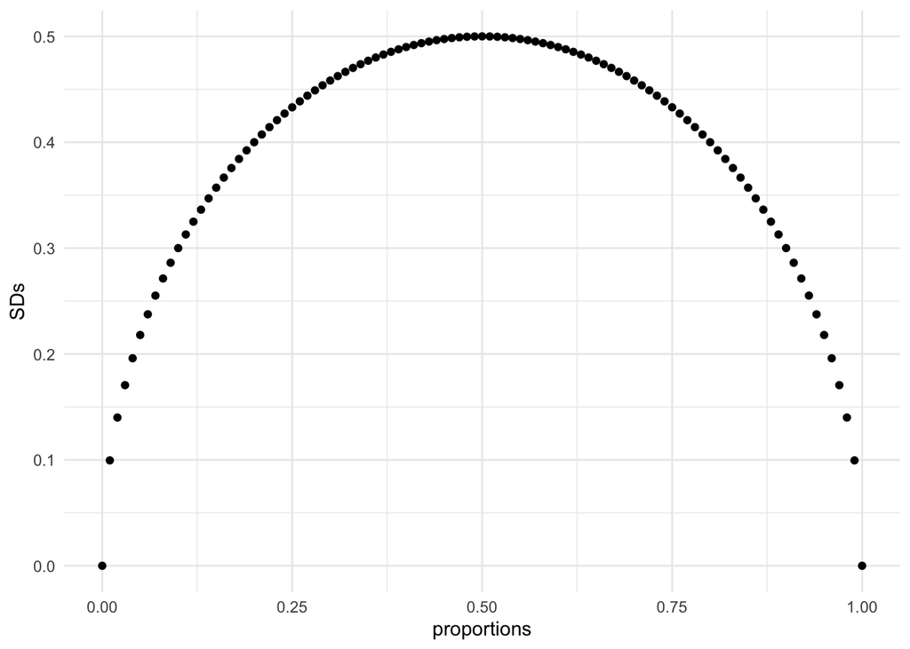

```r
# A visualization of the intuition behind this estimator:
# distribution of SDs drawn from Bernoulli distribution

proportions <- seq(from = 0, to = 1, by = 0.01)
SDs <- as.numeric(lapply(X = proportions, FUN = function(p){sqrt(p * (1 - p))}))

ggplot() + geom_point(aes(proportions, SDs)) + theme_minimal()
```

```r
# test: what's a DIP that corresponds to approximately d = 0.28,
# our overall average
dip_calc(0.05, 0.015)
```

```
## [1] 0.288
```

## robustness checks, alternate specifications, and alternate visualizations

Everything that follows is exploratory and not included in the paper or appendix

### Plotting

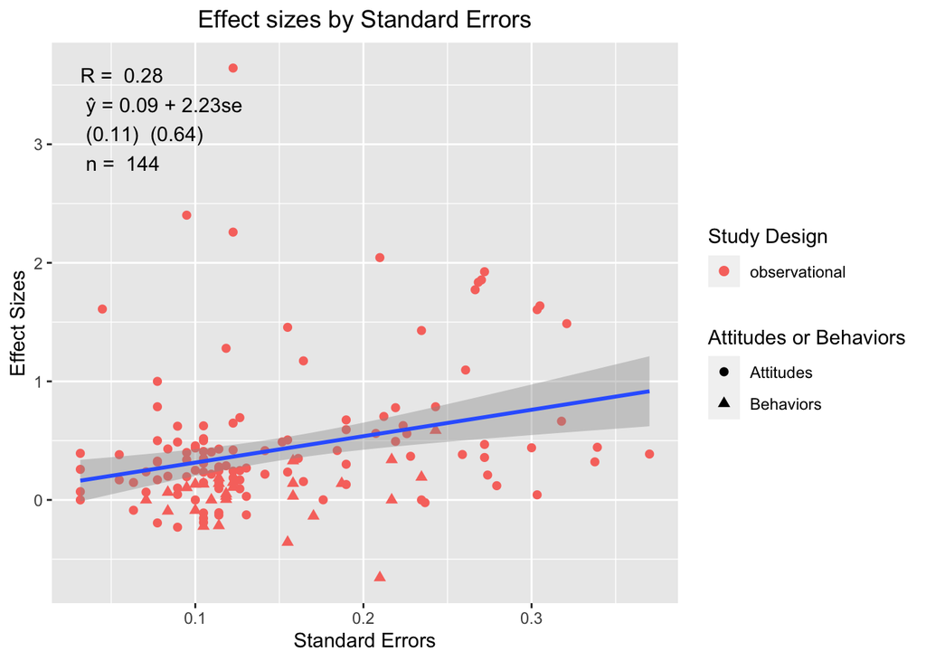

```
##
## $`quasi-experimental`
```

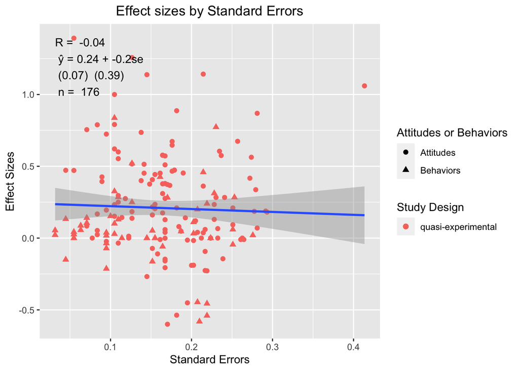

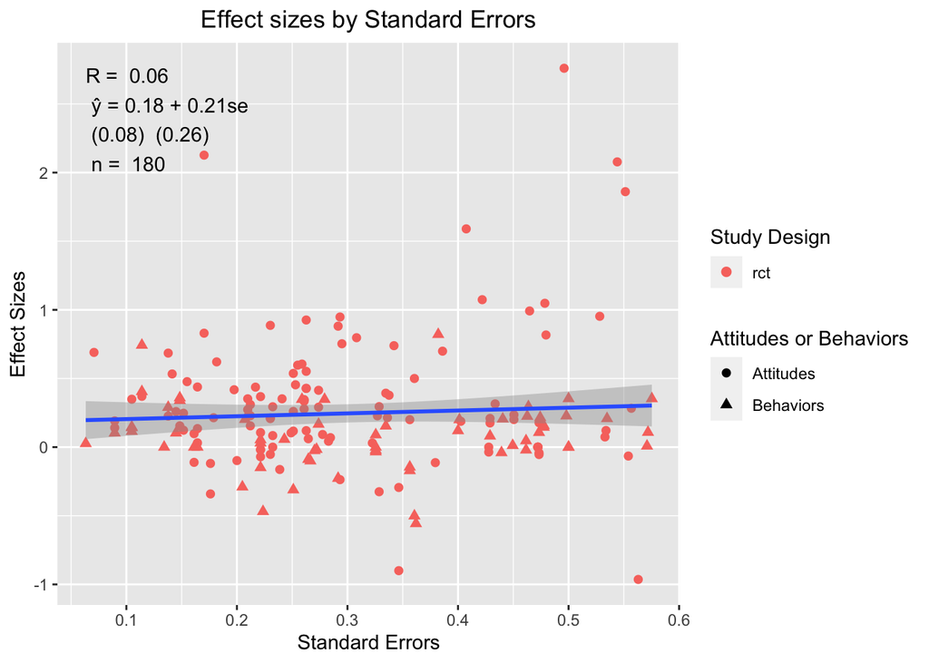

```r
dat %>%
  split(.$study_design) %>%
  map(.x = ., .f = ~dplot(sa_data = ., dot_size = 2, condense = F,
                          dot_informative = T))
```

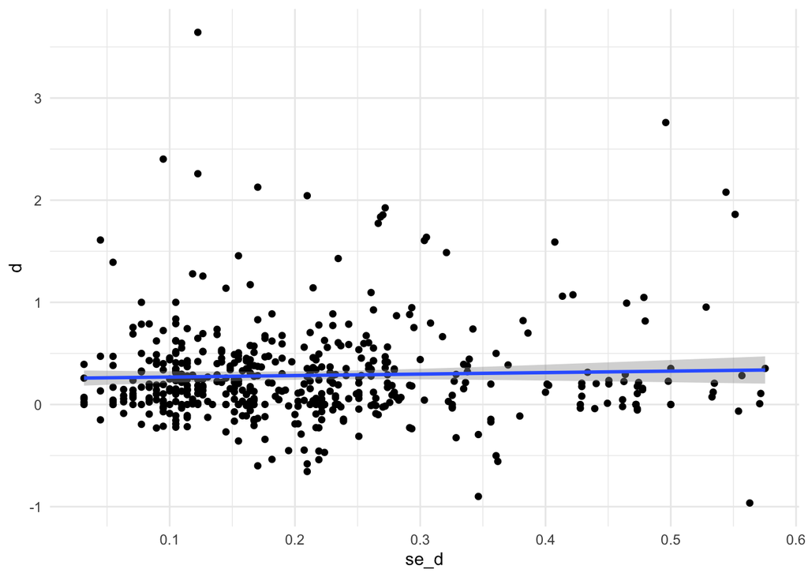

```r
# overall linear plot
dat %>%
ggplot(aes(x = se_d, y = d)) +
  geom_point() +
  geom_smooth(method = 'lm') +
  theme_minimal()
```

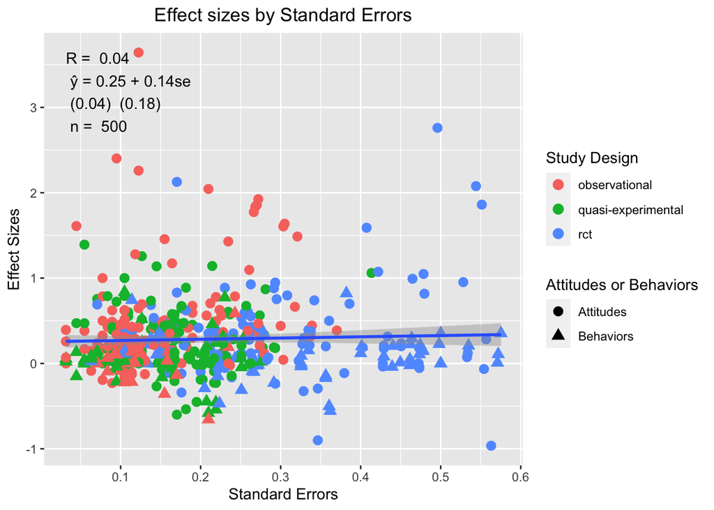

```r
dplot(condense = F)
```

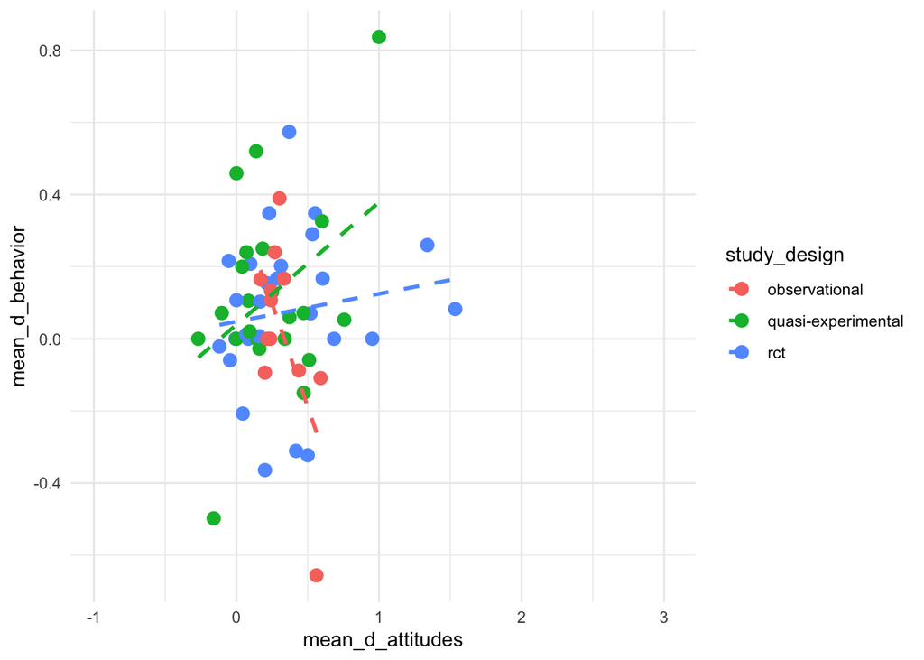

```r
## Relationship between attitudes and behaviors

has_both %>%
  ggplot(aes(x = mean_d_attitudes,
             y = mean_d_behavior,
             color = study_design)) +
  geom_point(size = 3) +
  geom_smooth(method = 'lm', se = F, lty = 'dashed') +
  theme_minimal()
```

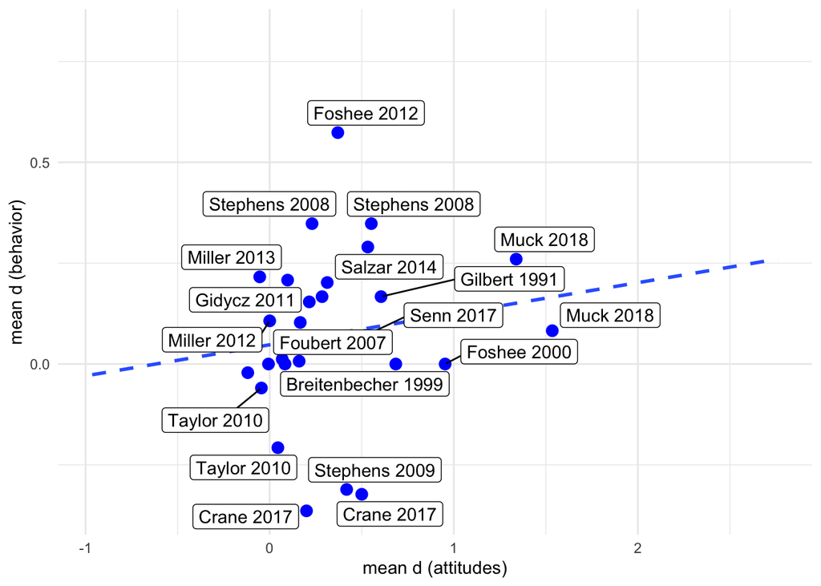

```r
# now same with RCTs, and with study labels
has_both %>%
  filter(study_design == 'rct') %>%
  ggplot(mapping = aes(x = mean_d_attitudes, y = mean_d_behavior)) +
  geom_point(size = 3, color = 'blue') +
  geom_smooth(aes(fill = NULL), lty = "dashed", fullrange = TRUE,
              method = "lm",
              show.legend = FALSE, alpha = .1, se = F) +
  geom_label_repel(mapping = aes(label = labels)) +
  theme_minimal() +
  labs(x = "mean d (attitudes)",
       y = "mean d (behavior)")
```

```r
# actually kind of a cool plot when you zoom in
```